# act

## Ecart absolu des coefficients :

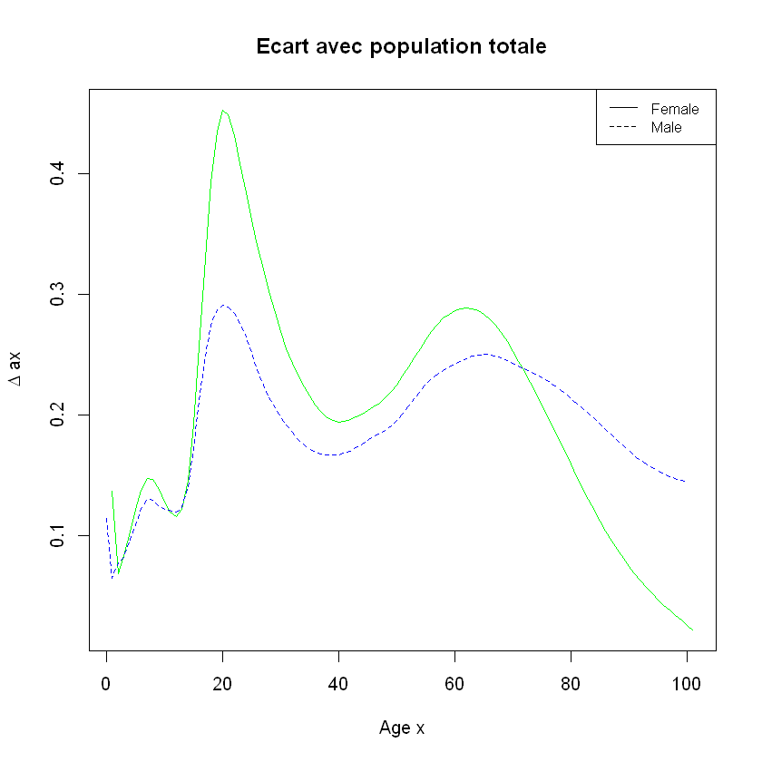

```r
plot(lca.total$ax-lca.female$ax, main="Ecart avec population totale", xlab="Age x", ylab=expression(paste(Delta, " ax")), type="l" , col='green')
lines(x=lca.male$age, y=lca.male$ax-lca.total$ax, main="delta", lty=2 , col ="blue")
legend("topright",c("Female","Male"), cex=0.8, lty=1:2)
```

- On constate un plus grand écart de mortalité chez les femmes entre 20 et 30 ans que chez les hommes jusqu’à l’âge de 70 ans. La tendance s’inverse puisqu’au delà, l’écart de mortalité est plus grand pour les hommes.

# Paramètre $k_t$ :

[figure not shown]

```r
plot(lca.total$kt, xlab="Year", main="Coef. kt sur données britanniques",ylab="kt", type="l",ylim=c(-100, 100))
lines(lca.male$year, y=lca.male$kt, main="kt", lty=2 , col="blue")
lines(lca.female$year, y=lca.female$kt, main="kt", lty=2 , col ="red")
legend("topright", c("Male","Female"), cex=0.8, lty=1:2)
```

- La valeur $k_t$ est en chute constante. On remarque un pic de la valeur de kt autour de la deuxième guerre mondiale.